# Segundo parcial

Natividad Oswaldo Pérez Medina

2025-04-08

# Series de tiempo

## Segundo parcial

### Problema 1

Dados los siguientes modelos:

- **Modelo 1** $x_t = −2x_{t−2} + w_t$
- **Modelo 2** $x_t = −16x_{t−2} − 2x_{t−1} + w_t$

determine si son estacionarios o no estacionarios, explíque cómo lo hace.

#### Respuesta

- **Modelo 1**

Entendiendolo como un *proceso autorregresivo de orden 2* donde el coeficiente de $x_{t-1}$ es 0, podemos plantearlo de la siguiente forma

$$x_t + 0x_{t-1} + 2x_{t−2} = w_t$$

Por lo que, para calcular las raíces de su *polinomio característico* tenemos:

$$1 + 2B^2 = 0$$

Esto significa que $B^2=-\frac{1}{2}$ por lo que $B=±\frac{i}{\sqrt2}$, estas son raíces complejas con modulo $|B| = \frac{1}{\sqrt2}$, que es aproximadamente 0.707. Dado que este valor no excede la unidad, entonces estamos hablando de un *proceso no estacionario*

- **Modelo 2**

Entendiendolo como un *proceso autorregresivo de orden 2*, podemos plantearlo de la siguiente forma

$$x_t + 2x_{t-1} + 16x_{t−2} = w_t$$

Por lo que, para calcular las raíces de su *polinomio característico* tenemos:

$$1 + 2B + 16B^2 = 0$$

Que tiene la siguiente solución:

$$B = \frac{-1±i\sqrt{15}}{16}$$

Cuando calculamos el modulo del resultado obtenido llegamos al valor $0.25$, el cual nuevamente no excede la unidad, por lo que podemos decir que este es un *proceso no estacionario*

### Problema 2

Simule un proceso autorregresivo de orden 2 con los valores alfa que usted quiera, grafíquelo y calcule sus correlogramas simple y parcial.

#### Respuesta

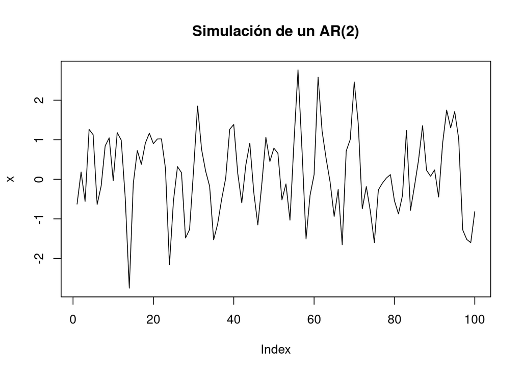

```r
set.seed(1)           # Para fijar una semilla
x <- w <- rnorm(100)
for (t in 3:100)
{
  x[t] <- 0.5 * x[t - 1] - 0.3 * x[t - 2] + w[t]
}
plot(x, type = "l", main = "Simulación de un AR(2)")   # Gráfica de la serie
```

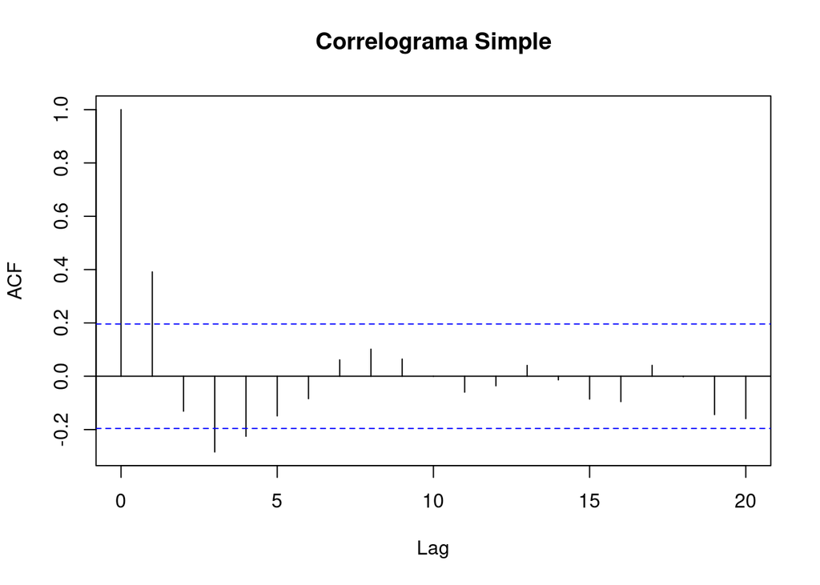

```r
acf(x, main = "Correlograma Simple")                # Correlograma simple
```

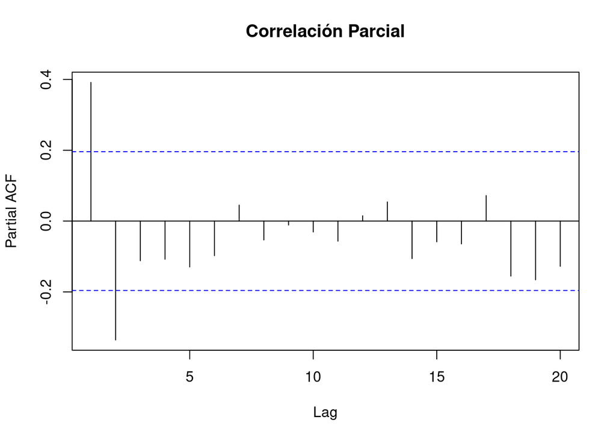

```r
pacf(x, main = "Correlación Parcial")               # Correlograma parcial
```

### Problema 3

Para los datos dados ajuste a un modelo autorregresivo, encuentre su orden, los valores de las alfas y diga si el ajuste es correcto y porque.

#### Respuesta

```r
# Aplicando el método "mle" en el proceso AR(2) del ejercicio anterior
x.ar <- ar(x, method = "mle")

# Para saber el orden que estima el método
x.ar$order
```

```
## [1] 2
```

```r
# Para saber el valor de los coeficientes estimados
x.ar$ar
```

```
## [1]  0.5231293 -0.3375427
```

##### Sobre el ajuste del modelo

Para saber si el modelo el adecuado observamos su función de autocorrelación parcial

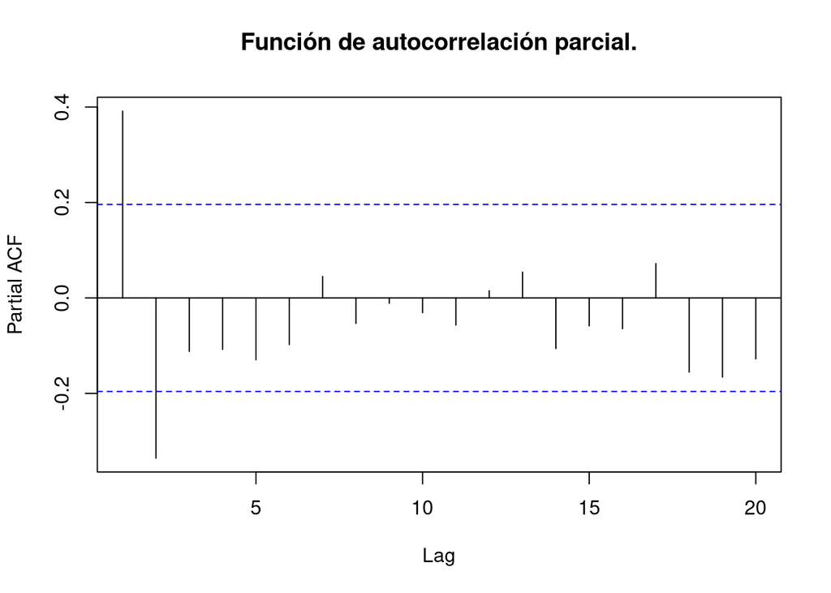

```r
pacf(x,main="Función de autocorrelación parcial.")
```

Únicamente vemos 2 valores significativamente diferentes de 0, fuera de las líneas azules, lo que apunta a que un modelo de *segundo grado* es apropiado para los datos, esto concuerda con el orden encontrado por `ar()`, por lo que podemos decir que el ajuste es correcto.

### Problema 4

Simule una serie de tiempo con una tendencia cuadrática, es decir, escoja una función para la pendiente y agregue un proceso autorregresivo. Gráfique la serie de tiempo y el correlograma de los residuos.

#### Respuesta

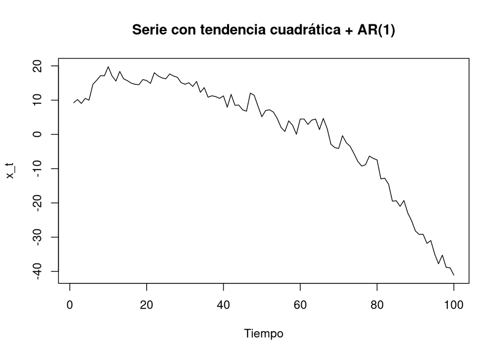

```r
# Simulación de una serie con tendencia cuadrática y ruido AR(1)
n <- 100
Time <- 1:n

# Simulamos componente AR(1)
w <- rnorm(n, sd = 2)
z <- numeric(n)
z[1] <- w[1]
for (t in 2:n) {
  z[t] <- 0.7 * z[t - 1] + w[t]
}

# Tendencia cuadrática
Trend <- 10 + 0.5 * Time - 0.01 * Time^2

# Serie total: tendencia + componente AR(1)
x <- Trend + z

# Gráfica de la serie
plot(Time, x, type = "l", main = "Serie con tendencia cuadrática + AR(1)", ylab = "x_t", xlab = "Tiempo")
```

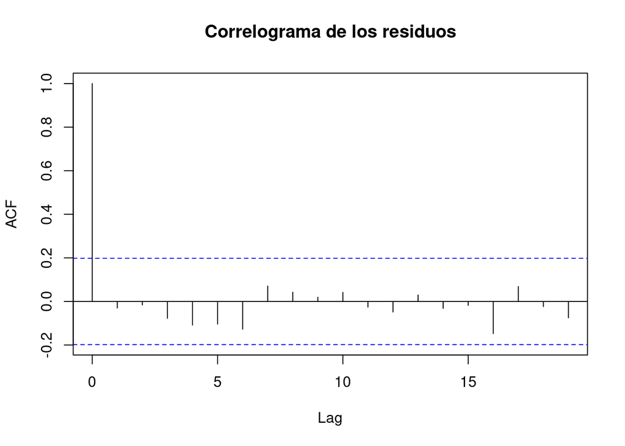

```r
# Para el correlograma de los residuos
xres <- x.ar$res
acf(xres[3:100],main="Correlograma de los residuos")
```

### Problema 5

Ajuste la serie anterior por medio de mínimos cuadrados ordinarios y después con mínimos cuadrados generalizados. Asegúrese de que la correlación que tome es la correcta.

#### Respuesta

```r
# Por el método de mínimos cuadrados ordinarios
modelo_ols <- lm(x ~ Time + I(Time^2))
summary(modelo_ols)
```

```
##
## Call:
## lm(formula = x ~ Time + I(Time^2))
##
## Residuals:
##     Min      1Q  Median      3Q     Max
## -4.9316 -1.9544 -0.2795  1.8490  6.5633
##
## Coefficients:
##               Estimate Std. Error t value Pr(>|t|)
## (Intercept) 10.8780252  0.8311089   13.09   <2e-16 ***
## Time         0.4225905  0.0379839   11.13   <2e-16 ***
## I(Time^2)   -0.0091713  0.0003644  -25.17   <2e-16 ***
## ---
## Signif. codes:  0 '***' 0.001 '**' 0.01 '*' 0.05 '.' 0.1 ' ' 1
##
## Residual standard error: 2.715 on 97 degrees of freedom
## Multiple R-squared:  0.973,  Adjusted R-squared:  0.9725
## F-statistic:  1751 on 2 and 97 DF,  p-value: < 2.2e-16
```

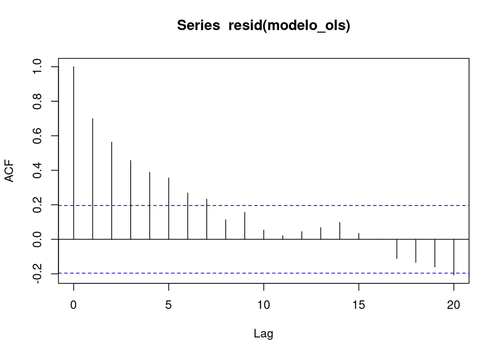

```r
# Para ver la autocorrelación
acf(resid(modelo_ols))
```

```r
# Por el método de mínimos cuadrados generalizados
library(nlme)
modelo_gls <- gls(x ~ Time + I(Time^2), correlation = corAR1(0.7))
summary(modelo_gls)
```

```
## Generalized least squares fit by REML
##   Model: x ~ Time + I(Time^2)
##   Data: NULL
##        AIC      BIC    logLik
##   439.6417 452.5153 -214.8209
##
## Correlation Structure: AR(1)
##  Formula: ~1
##  Parameter estimate(s):
##       Phi
## 0.7588151
##
## Coefficients:
##                 Value Std.Error    t-value p-value
## (Intercept) 10.187792 2.1166541   4.813159       0
## Time         0.458838 0.0966430   4.747761       0
## I(Time^2)   -0.009538 0.0009234 -10.328399       0
##
##  Correlation:
##           (Intr) Time
## Time      -0.841
## I(Time^2)  0.707 -0.965
##
## Standardized residuals:
##         Min          Q1         Med          Q3         Max
## -1.72725431 -0.62301378 -0.05215275  0.62002341  2.25819034
##
## Residual standard error: 2.965858
## Degrees of freedom: 100 total; 97 residual
```

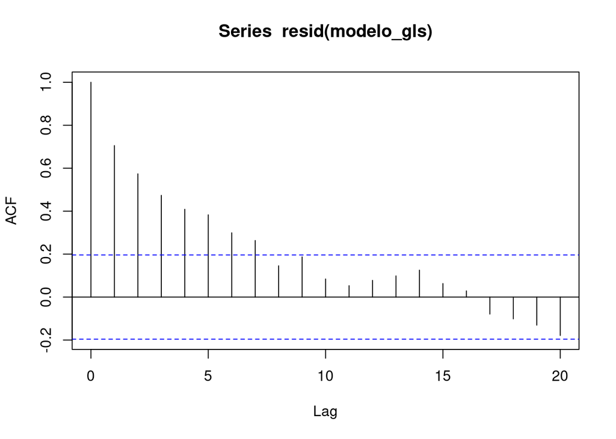

```r
# Para ver la autocorrelación
acf(resid(modelo_gls))
```